# Highschool data analysis

# Part 1

First we are going to load the libraries we need to use:

```r
# warning=False above stops us from seeing the warning messages
# produced from function name clashes
library(readxl)
library(dplyr)
```

```r
library(ggplot2)
```

Next we will load our data file and check the names and dimensions:

```r
student_data <- read_excel("hsb2.xlsx")
```

```
## readxl works best with a newer version of the tibble package.
## You currently have tibble v1.4.2.
## Falling back to column name repair from tibble <= v1.4.2.
## Message displays once per session.
```

```r
names(student_data)
```

```
##  [1] "id"      "female"  "race"    "ses"     "schtyp"  "prog"    "read"
##  [8] "write"   "math"    "science" "socst"
```

```r
dim(student_data)
```

```
## [1] 200  11
```

Processing our data with `dlpyr` but without pipes:

```r
student_data <- rename(student_data, school_type=schtyp)
student_data <- filter(student_data, ses==1)
student_data <- select(student_data, id, female, race, read, write)
student_data <- arrange(student_data, desc(read))
student_data
```

| id | female | race | read | write |
| --- | --- | --- | --- | --- |
| 125 | 1 | 4 | 68 | 65 |
| 23 | 1 | 2 | 65 | 65 |
| 81 | 0 | 4 | 63 | 43 |
| 3 | 0 | 1 | 63 | 65 |
| 149 | 0 | 4 | 63 | 49 |
| 135 | 1 | 4 | 63 | 60 |
| 77 | 1 | 4 | 61 | 59 |
| 35 | 1 | 1 | 60 | 54 |
| 70 | 0 | 4 | 57 | 52 |
| 33 | 1 | 2 | 57 | 65 |

[output cut: 37 more lines]

Now showing how this can be done using pipes:

```r
student_data <- read_excel("hsb2.xlsx")
student_data %>% rename(school_type=schtyp) %>%
  filter(ses==1) %>%
  select( id, female, race, read, write) %>%
  arrange(desc(read)) %>%
  group_by(race) %>%
  summarise(count=n(), av_read=mean(read), av_write=mean(write))
```

| race | count | av_read | av_write |
| --- | --- | --- | --- |
| 1 | 9 | 45.44444 | 46.11111 |
| 2 | 3 | 58.00000 | 58.00000 |
| 3 | 11 | 44.45455 | 48.09091 |
| 4 | 24 | 49.87500 | 52.54167 |

Example of using ggplot.

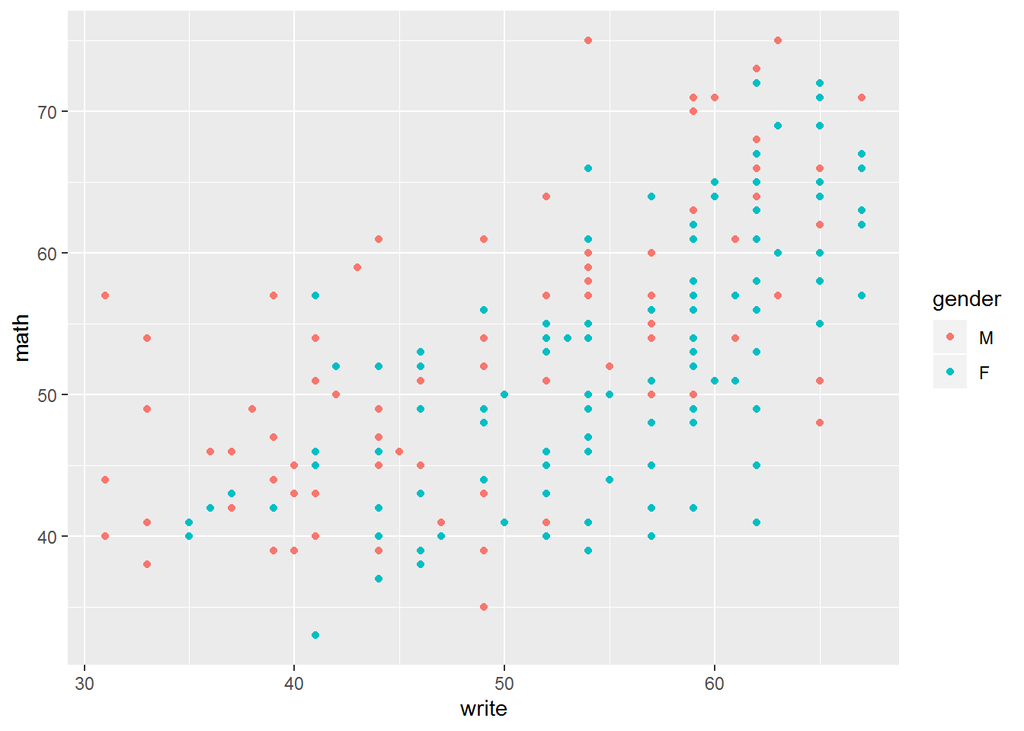

```r
library(ggplot2)
student_data %>%
  mutate(gender = factor(female, labels=c("M","F"))) %>%
  ggplot() +
  geom_point(mapping = aes(x = write, y = math, color = gender))
```

Note it seems there is a general correlation between write and math scores, boys have lower write scores on average (and some boys have low write scores but higher than expected math scores).

# Part 2

Next let’s see alternative example of using pipes `%>%` and the `dplyr` library functions:

```r
student_data <- read_excel("hsb2.xlsx")
race_labels = c("hispanic", "asian", "african-american", "white")
prog_labels = c("general","academic","vocational")
student_data_public <- student_data %>%
  mutate(gender = factor(female, labels=c("M","F")),
         social_economic_group = factor(ses, labels=c("L","M","H")),
         race = factor(race, labels=race_labels),
         program = factor(prog, labels=prog_labels)) %>%
  filter(schtyp == 1) %>%
  select(-schtyp)
```

```r
student_data_public %>%
  group_by(gender) %>%
  summarise(count=n(),
            science=mean(science),
            write=mean(write),
            read=mean(read),
            math=mean(math),
            )
```

| gender | count | science | write | read | math |
| --- | --- | --- | --- | --- | --- |
| M | 77 | 52.89610 | 49.36364 | 52.35065 | 52.31169 |
| F | 91 | 50.48352 | 54.69231 | 51.41758 | 52.18681 |

Looks like males have lower writing scores than females on average is this significant at the 0.01 level?

```r
t.test(write~gender,sig=0.01, data=student_data_public)
```

```
##
##  Welch Two Sample t-test
##
## data:  write by gender
## t = -3.5767, df = 144.58, p-value = 0.0004738
## alternative hypothesis: true difference in means is not equal to 0
## 95 percent confidence interval:
##  -8.273318 -2.384024
## sample estimates:
## mean in group M mean in group F
##        49.36364        54.69231
```

We can see the p-val indicates the probability of seeing a difference of ~5 is 0.00047 under the null hypothesis that there is no difference in the writing scores of males and females. It was below our chosen significance level so we say we the data provides evidence to reject the null hypothesis and accept the alternative hypothesis that the mean writing scores for males and females differs.

The test also provides a confidence interval for the true population difference to be between 2.4 and 8.3 marks.

We can examine the difference in the distributions using a ggplot boxplot:

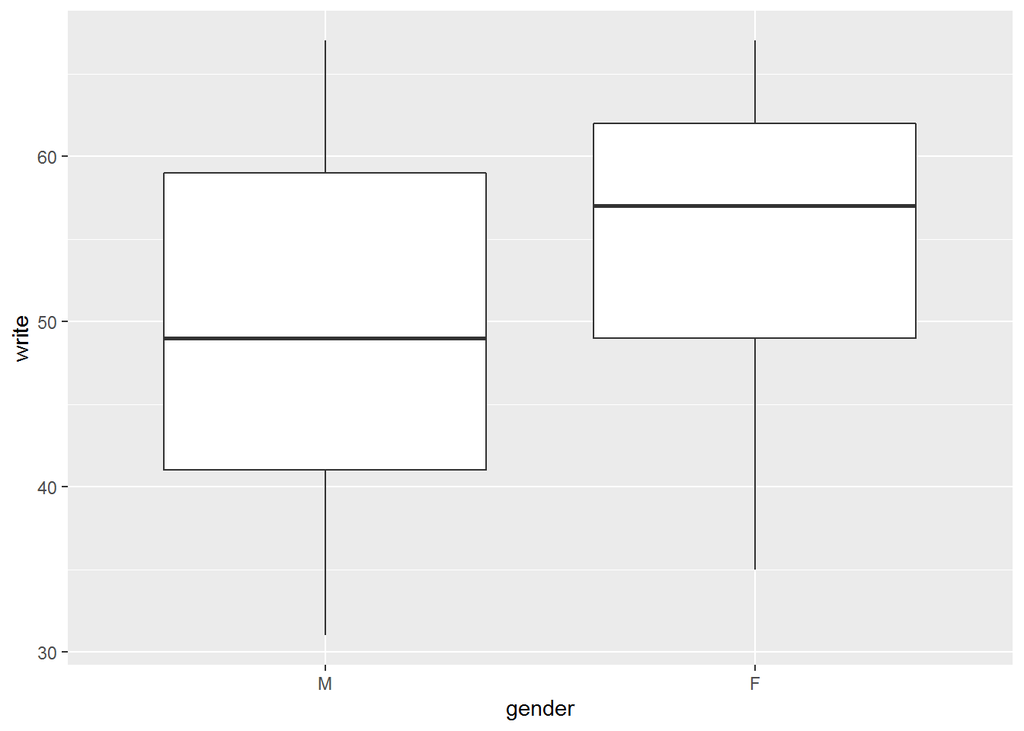

```r
ggplot(data = student_data_public,
       mapping = aes(x = gender, y = write)) +
  geom_boxplot()
```

Or we can use a density plot (sort of a smoothed histogram):

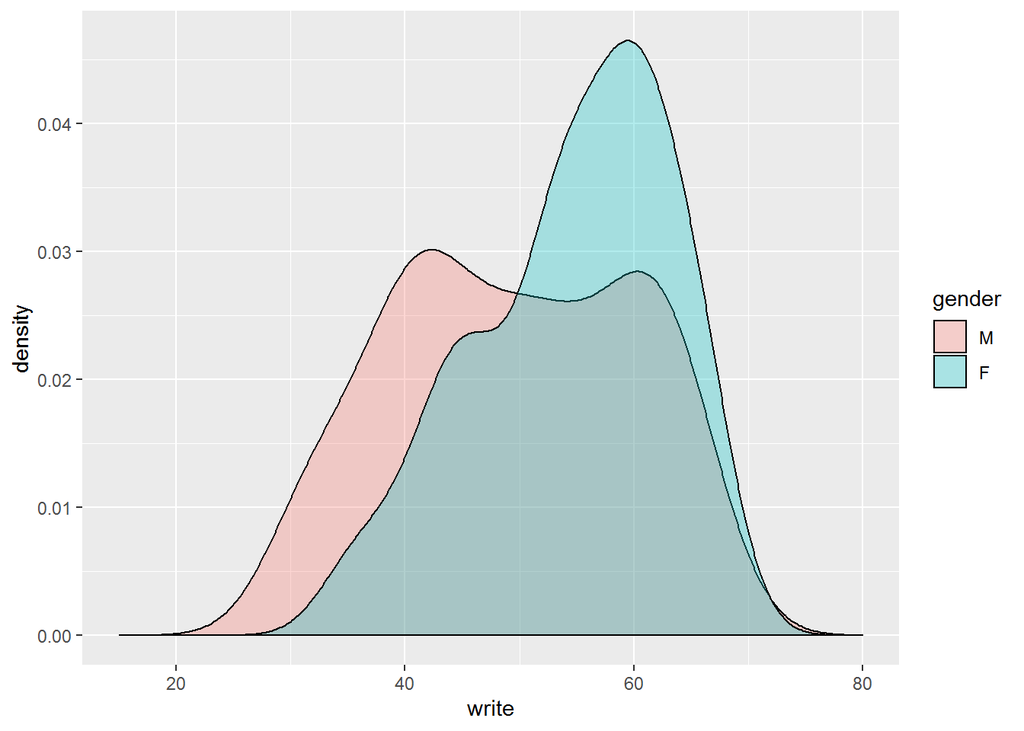

```r
ggplot(student_data_public, aes(write, fill =gender )) +
  geom_density(alpha=0.3)+xlim(15,80)
```

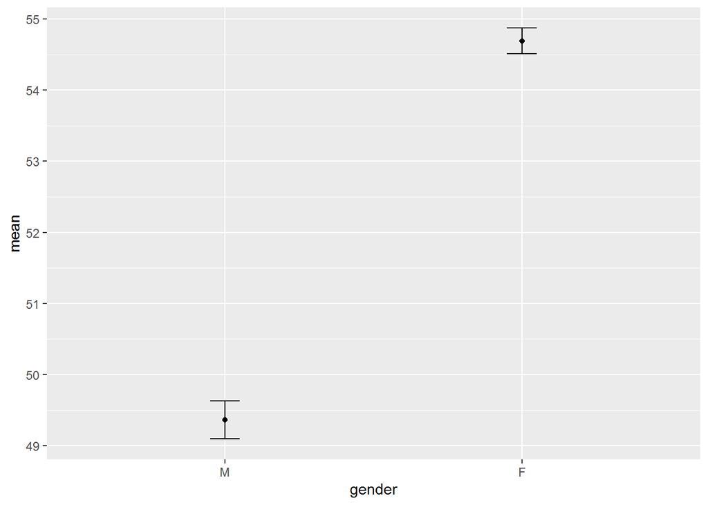

```r
student_data_public %>%
  group_by(gender) %>%
  summarise(mean=mean(write),
            se=sd(write)/n(),
            ub=mean+1.96*se,
            lb=mean-1.96*se
            ) %>%
  ggplot(aes(x=gender, y=mean)) +
    geom_errorbar(aes(ymin=lb, ymax=ub), width=.1) +
    geom_point()
```